# Subset to Region

B Steele, Colorado State University, ROSSyndicate

last updated Sept 10, 2026

This code reduces the 5-day matchups to those in the HUC4’s of a 6-state region including Colorado, Wyoming, Utah, Idaho, Monana and New Mexico and applies some QA filters to the data to create a machine learning dataset.

## Data prep

```r
# load libraries
library(tidyverse)
library(sf)
library(arrow)
library(tigris)
library(tmap)
library(hydrogeofetch)

# read in 5-day match
sdd_5d <- read_parquet("aquamatch_files/sdd_regional_siteSR_matchups_5d.parquet")
```

### Reduce AOI to Mountain West HUC4’s

Get site info.

```r
sites <- read_csv("aquamatch_files/siteSR_collated_WQP_NWIS_sites_with_NHD_info_2025-06-04.csv")
sites_filtered <- sites %>%
  filter(siteSR_id %in% unique(sdd_5d$siteSR_id)) %>%
  st_as_sf(., coords = c("WGS84_Longitude", "WGS84_Latitude"), crs = "EPSG:4326")
```

Filter to states we care about.

```r
states <- states(progress_bar = FALSE) %>%
  filter(STUSPS %in% c("CO", "WY", "UT", "ID", "MT", "NM"))
states_union <- states %>% st_union()
```

Grab all the HUC4’s from NHD and validate them

```r
# get_huc() kept timing out (HTTP 504) against the USGS pygeoapi service, even
# retried state-by-state, so instead download the national WBD geodatabase
# once (cached in aquamatch_files/) and filter to our HUC4's locally.
wbd_gdb <- download_wbd(outdir = "aquamatch_files/wbd_national")
```

```
## Extracting data ...
```

[output not shown]

```
## WBD data extracted to: aquamatch_files/wbd_national/WBD_National_GDB/WBD_National_GDB.gdb
```

```r
huc4_layer <- st_layers(wbd_gdb)$name %>%
  keep(~ grepl("HU4$", ., ignore.case = TRUE))

HUC4_national <- st_read(wbd_gdb, layer = huc4_layer, quiet = TRUE) %>%
  rename_with(tolower) %>%
  # WBD ships with Z values and a compound CRS (NAD83 + NAVD88 height);
  # transforming a 2D CRS into that compound CRS silently breaks (no vertical
  # grid to invent a Z), so drop Z here - horizontal datum is then plain NAD83
  st_zm(drop = TRUE, what = "ZM")

# standardize the geometry column name to "geometry" (FileGDB layers are
# often read in with the geometry column named "shape")
geom_col <- attr(HUC4_national, "sf_column")
if (geom_col != "geometry") {
  names(HUC4_national)[names(HUC4_national) == geom_col] <- "geometry"
  st_geometry(HUC4_national) <- "geometry"
}

# reset (not transform) the CRS now that only the horizontal NAD83 datum
# remains, matching states_union - no reprojection needed
st_crs(HUC4_national) <- st_crs(states_union)
# reduce from the national layer to just the HUC4's touching our 6-state AOI
HUC4 <- HUC4_national %>%
  st_make_valid() %>%
  st_filter(states_union)

HUC4v <- st_make_valid(HUC4)
```

And then assess overlapping area - here we want to inlcude HUCs that overlap the 6-state area by at least 50%.

```r
overlap_areas <- st_make_valid(HUC4v) %>%
  st_intersection(st_make_valid(states_union)) %>%
  mutate(overlap_area = st_area(geometry)) %>%
  st_drop_geometry() %>%
  select(huc4, overlap_area)
# calculate proportion overlap, filter for those greater than/equal to 50%
HUC4_filtered <- HUC4v %>%
  left_join(overlap_areas, by = "huc4") %>%
  mutate(
    overlap_area = coalesce(overlap_area, units::set_units(0, "m^2")),
    overlap_frac = as.numeric(overlap_area / st_area(geometry))
  ) %>%
  filter(overlap_frac >= 0.50)

# add huc info and filter to this extent
regional_sites <- sites_filtered %>%
  st_transform(st_crs(HUC4_filtered)) %>%
  st_join(HUC4_filtered %>% select(huc4), left = FALSE)

# add sdd info back, carrying along each site's HUC4 label
regional_sdd <- sdd_5d %>%
  filter(siteSR_id %in% regional_sites$siteSR_id) %>%
  left_join(
    regional_sites %>%
      st_drop_geometry() %>%
      select(siteSR_id, HUC4 = huc4) %>%
      # guard against a site sitting exactly on a shared HUC4 boundary,
      # which could otherwise match more than one polygon in the spatial join
      distinct(siteSR_id, .keep_all = TRUE),
    by = "siteSR_id"
  )
```

## QA the data

Make sure we’re using the observation closest in time to the measurement. This assures we’re not using multiple satellites for the same data point in our training dataset. We will also export those that are not included as a possible additional test set.

```r
# grab the observation closes in date to a satellite flyover
reg_sdd_closest <- regional_sdd %>%
  arrange(abs(time_diff), mission) %>%
  slice(1, .by = c("subgroup_id"))

# let's also do an anti-join here of the other observations so that we have an
# additional validation dataset to play with.
reg_sdd_additional <- anti_join(regional_sdd, reg_sdd_closest)
```

[output not shown]

```r
write_feather(reg_sdd_additional, "aquamatch_files/regional_sdd_not_closest.feather")
```

## Visualize data

Let’s look at some longer records to do a sanity check to make sure that all the filters worked correctly.

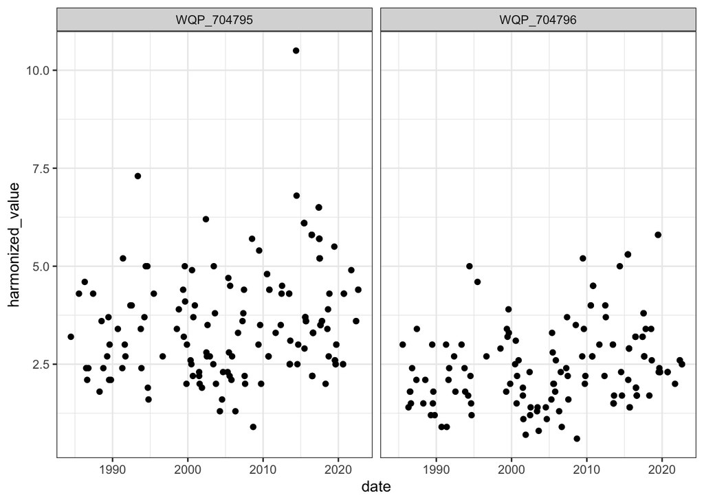

```r
# summarize by site for plotting
regional_site_summary <- reg_sdd_closest %>%
  st_as_sf(coords = c("lon", "lat"),
           crs = "EPSG:4326") %>%
  summarize(n = n(), .by = c(siteSR_id, geometry)) %>%
  arrange(n)

# look at some of the records with a lot of data
regional_long_record <- regional_site_summary %>%
  filter(n > 100) %>%
  left_join(., reg_sdd_closest)
ggplot(regional_long_record, aes(x = date, y = harmonized_value)) +
  geom_point() +
  facet_wrap(siteSR_id ~ .) +
  theme_bw()
```

Look at data spatially by site

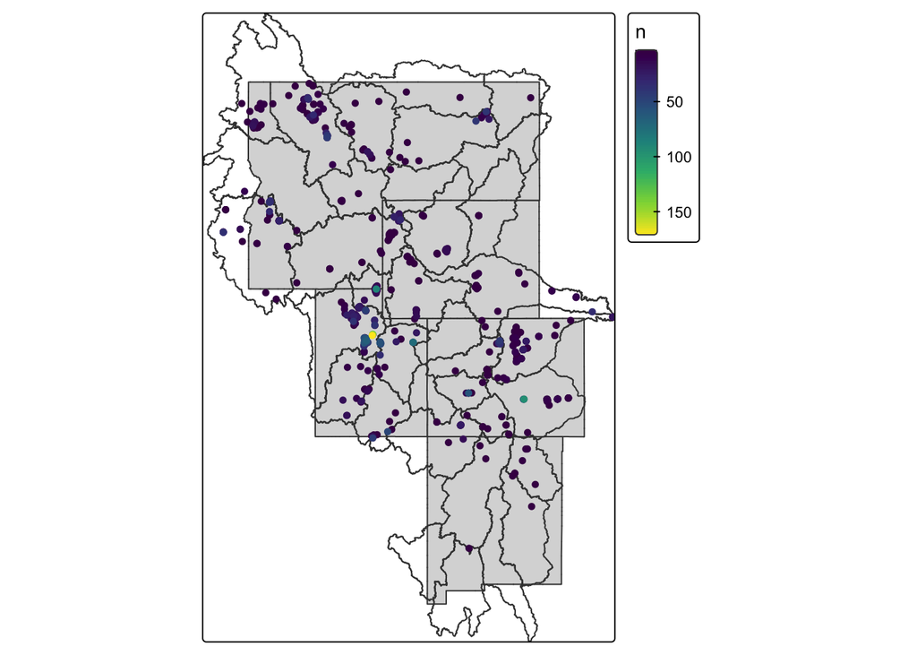

```r
tm_shape(HUC4_filtered) +
  tm_shape(states %>%
             st_transform(st_crs(HUC4_filtered))) +
  tm_polygons() +
  tm_shape(HUC4_filtered) +
  tm_polygons(fill_alpha = 0) +
  tm_shape(regional_site_summary %>%
             st_transform(st_crs(HUC4_filtered))) +
  tm_dots("n",
          fill.scale = tm_scale_continuous(values = "viridis"))
```

And summarize by HUC4

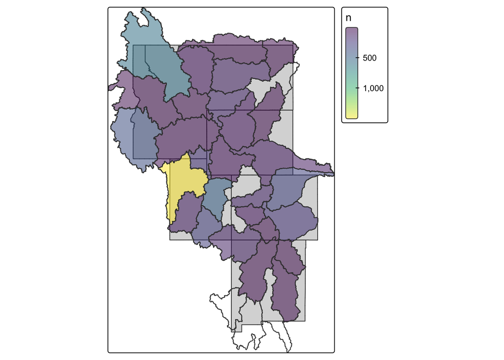

```r
regional_huc_summary <- reg_sdd_closest %>%
    st_as_sf(coords = c("lon", "lat"),
           crs = "EPSG:4326") %>%
  st_transform(., st_crs(HUC4_filtered)) %>%
  st_join(HUC4_filtered, .) %>%
  summarize(n = sum(!is.na(siteSR_id)), .by = c(huc4, geometry))


tm_shape(HUC4_filtered) +
  tm_shape(states %>%
             st_transform(st_crs(HUC4_filtered))) +
  tm_polygons() +
  tm_shape(HUC4_filtered) +
  tm_polygons(fill_alpha = 0) +
  # drop 0-count HUC4s so they're left uncolored (outline only) instead of
  # taking the low end of the viridis scale
  tm_shape(regional_huc_summary %>% filter(n > 0)) +
  tm_polygons("n",
              fill.scale = tm_scale_continuous(values = "viridis"),
              fill_alpha = 0.5)
```

## Export data

```r
write_feather(reg_sdd_closest,
              "aquamatch_files/filtered_regional_sdd.feather")
```

Save the HUC4 and state boundaries as their own geodatabases so later scripts can just read these back in instead of re-running the HUC4 download/filter and states() pull.

```r
st_write(HUC4_filtered,
         dsn = "aquamatch_files/huc4_filtered.gdb",
         layer = "huc4_filtered",
         driver = "OpenFileGDB",
         append = FALSE,
         quiet = TRUE)

st_write(states,
         dsn = "aquamatch_files/states.gdb",
         layer = "states",
         driver = "OpenFileGDB",
         append = FALSE,
         quiet = TRUE)
```